# Vehicle LoanDefaultPrediction_EDA_Modeling

*Project Scope*  
**Objectives**  
To reduce financial losses from vehicle loan defaults, this project will analyze key factors that lead to defaults and develop a model to predict potential defaulters.  
**Key Deliverables**

Exploratory Data Analysis (EDA): Understanding the characteristics of the data, treating missing values, and handling outliers.

Feature Selection & Importance Analysis: Identifying the primary factors contributing to loan defaults.

Model Development: Using logistic regression to build a predictive model for identifying potential defaulters.

Evaluation: Assessing the model's accuracy.

**Dataset Overview:**  
The dataset comprises 41 attributes, capturing various customer details, loan specifics, and historical financial behaviors, serving as a foundation for our analysis.

This project aims to provide financial institutions with a predictive tool and insights to enhance their loan decision-making process.

Preliminary Data Analysis

1.Import Libraries

```python
import pandas as pd
import seaborn as sns
import numpy as np
from pyproj import Proj, transform
from datetime import datetime
from IPython.display import display

import matplotlib.pyplot as plt
import matplotlib.ticker as mtick

from sklearn.metrics import classification_report, accuracy_score
from sklearn.model_selection import train_test_split
from sklearn.linear_model import LogisticRegression
from sklearn.preprocessing import StandardScaler

from IPython.core.display import display, HTML
```

2.Read datasets

```python
loan =pd.read_excel('../../02 Data/Original Data/internal/data.xlsx')
```

3.Quickly explore the data

```python
display(loan.head())
number_of_rows = loan.shape[0]
print ( 'This dataset includes {} observations and {} columns.'.format(loan.shape[0] , loan.shape[1]))
```

|  | UniqueID | disbursed_amount | asset_cost | ltv | branch_id | supplier_id | manufacturer_id | Current_pincode_ID | Date.of.Birth | Employment.Type | ... | SEC.SANCTIONED.AMOUNT | SEC.DISBURSED.AMOUNT | PRIMARY.INSTAL.AMT | SEC.INSTAL.AMT | NEW.ACCTS.IN.LAST.SIX.MONTHS | DELINQUENT.ACCTS.IN.LAST.SIX.MONTHS | AVERAGE.ACCT.AGE | CREDIT.HISTORY.LENGTH | NO.OF_INQUIRIES | loan_default |
| --- | --- | --- | --- | --- | --- | --- | --- | --- | --- | --- | --- | --- | --- | --- | --- | --- | --- | --- | --- | --- | --- |
| 0 | 420825 | 50578 | 58400 | 89.55 | 67 | 22807 | 45 | 1441 | 1984-01-01 | Salaried | ... | 0 | 0 | 0 | 0 | 0 | 0 | 0yrs 0mon | 0yrs 0mon | 0 | 0 |
| 1 | 417566 | 53278 | 61360 | 89.63 | 67 | 22807 | 45 | 1497 | 1985-08-24 | Self employed | ... | 0 | 0 | 0 | 0 | 0 | 0 | 0yrs 0mon | 0yrs 0mon | 0 | 0 |
| 2 | 539055 | 52378 | 60300 | 88.39 | 67 | 22807 | 45 | 1495 | 1977-12-09 | Self employed | ... | 0 | 0 | 0 | 0 | 0 | 0 | 0yrs 0mon | 0yrs 0mon | 1 | 1 |
| 3 | 529269 | 46349 | 61500 | 76.42 | 67 | 22807 | 45 | 1502 | 1988-06-01 | Salaried | ... | 0 | 0 | 0 | 0 | 0 | 0 | 0yrs 0mon | 0yrs 0mon | 0 | 0 |
| 4 | 563215 | 43594 | 78256 | 57.50 | 67 | 22744 | 86 | 1499 | 1994-07-14 | Self employed | ... | 0 | 0 | 0 | 0 | 0 | 0 | 0yrs 0mon | 0yrs 0mon | 0 | 0 |

5 rows × 41 columns

```
This dataset includes 233154 observations and 41 columns.
```

```python
loan.info();
print("\n It seems that we have missing value for employee type.")
print(" Some variables need to be renamed; their current names are not compatible with Python conventions.")
```

```
<class 'pandas.core.frame.DataFrame'>
RangeIndex: 233154 entries, 0 to 233153
Data columns (total 41 columns):
 #   Column                               Non-Null Count   Dtype
---  ------                               --------------   -----
 0   UniqueID                             233154 non-null  int64
 1   disbursed_amount                     233154 non-null  int64
 2   asset_cost                           233154 non-null  int64
 3   ltv                                  233154 non-null  float64
 4   branch_id                            233154 non-null  int64
 5   supplier_id                          233154 non-null  int64
 6   manufacturer_id                      233154 non-null  int64
 7   Current_pincode_ID                   233154 non-null  int64
 8   Date.of.Birth                        233154 non-null  datetime64[ns]
 9   Employment.Type                      225493 non-null  object
```

[output cut: 36 more lines]

4.Data cleaning

-Renaming variables, replaceing "." by "_"

```python
loan.columns  = loan.columns.str.replace(".","_") ;
loan.columns
```

```
Index(['UniqueID', 'disbursed_amount', 'asset_cost', 'ltv', 'branch_id',
       'supplier_id', 'manufacturer_id', 'Current_pincode_ID', 'Date_of_Birth',
       'Employment_Type', 'DisbursalDate', 'State_ID', 'Employee_code_ID',
       'MobileNo_Avl_Flag', 'Aadhar_flag', 'PAN_flag', 'VoterID_flag',
       'Driving_flag', 'Passport_flag', 'PERFORM_CNS_SCORE',
       'PERFORM_CNS_SCORE_DESCRIPTION', 'PRI_NO_OF_ACCTS', 'PRI_ACTIVE_ACCTS',
       'PRI_OVERDUE_ACCTS', 'PRI_CURRENT_BALANCE', 'PRI_SANCTIONED_AMOUNT',
       'PRI_DISBURSED_AMOUNT', 'SEC_NO_OF_ACCTS', 'SEC_ACTIVE_ACCTS',
       'SEC_OVERDUE_ACCTS', 'SEC_CURRENT_BALANCE', 'SEC_SANCTIONED_AMOUNT',
       'SEC_DISBURSED_AMOUNT', 'PRIMARY_INSTAL_AMT', 'SEC_INSTAL_AMT',
       'NEW_ACCTS_IN_LAST_SIX_MONTHS', 'DELINQUENT_ACCTS_IN_LAST_SIX_MONTHS',
       'AVERAGE_ACCT_AGE', 'CREDIT_HISTORY_LENGTH', 'NO_OF_INQUIRIES',
       'loan_default'],
      dtype='object')
```

```python
loan.Employee_code_ID.unique().shape
```

```
(3270,)
```

-Finding and Dealing with missing vlaues

```python
loan.isna().sum()
```

```
UniqueID                                  0
disbursed_amount                          0
asset_cost                                0
ltv                                       0
branch_id                                 0
supplier_id                               0
manufacturer_id                           0
Current_pincode_ID                        0
Date_of_Birth                             0
Employment_Type                        7661
DisbursalDate                             0
State_ID                                  0
Employee_code_ID                          0
MobileNo_Avl_Flag                         0
Aadhar_flag                               0
PAN_flag                                  0
VoterID_flag                              0
Driving_flag                              0
Passport_flag                             0
PERFORM_CNS_SCORE                         0
PERFORM_CNS_SCORE_DESCRIPTION             0
PRI_NO_OF_ACCTS                           0
PRI_ACTIVE_ACCTS                          0
PRI_OVERDUE_ACCTS                         0
PRI_CURRENT_BALANCE                       0
PRI_SANCTIONED_AMOUNT                     0
PRI_DISBURSED_AMOUNT                      0
SEC_NO_OF_ACCTS                           0
SEC_ACTIVE_ACCTS                          0
SEC_OVERDUE_ACCTS                         0
SEC_CURRENT_BALANCE                       0
SEC_SANCTIONED_AMOUNT                     0
SEC_DISBURSED_AMOUNT                      0
PRIMARY_INSTAL_AMT                        0
SEC_INSTAL_AMT                            0
NEW_ACCTS_IN_LAST_SIX_MONTHS              0
DELINQUENT_ACCTS_IN_LAST_SIX_MONTHS       0
AVERAGE_ACCT_AGE                          0
CREDIT_HISTORY_LENGTH                     0
NO_OF_INQUIRIES                           0
loan_default                              0
dtype: int64
```

#### Missing value treatment for Employement_Type

#### Let's check if we could find Employement_Type by other columns like "asset_cost.

```python
loan.Employment_Type.unique()
```

```
array(['Salaried', 'Self employed', nan], dtype=object)
```

```python
salaried_mean = loan[loan.Employment_Type == 'Salaried'].asset_cost.mean()
self_employed_mean = loan[loan.Employment_Type == 'Self employed'].asset_cost.mean()
print("Asset_cost's average for Salaried EmploymentType : {} ". format(salaried_mean))
print("Aset_cost's average for Self Employed EmploymentType : {} ". format(self_employed_mean))
print("There is no significant difference in the averages between the two groups. Therefore, this variable may not be helpful for imputing Employment_type.")
```

```
Asset_cost's average for Salaried EmploymentType : 74395.27703406978
Aset_cost's average for Self Employed EmploymentType : 76578.66417518706
There is no significant difference in the averages between the two groups. Therefore, this variable may not be helpful for imputing Employment_type.
```

```python
#fig, axes = plt.subplots(1, 2, figsize=(12, 6))
#sns.boxplot(data = loan[loan.Employment_Type =='Self employed'] , y = 'asset_cost' , ax=axes[0])
#sns.boxplot(data = loan[loan.Employment_Type =='Salaried'] , y = 'asset_cost' , ax=axes[1])

#print("There is no significant difference, so we can not use asset_cost for Employment_Type imputation.")
```

### I used mode for missing value imputation

```python
loan.Employment_Type.fillna(loan.Employment_Type.mode()[0],inplace=True)
```

```python
missing_values = loan.isna().sum()
columns_with_missing_values = missing_values[missing_values > 0]
print(columns_with_missing_values)
```

```
Series([], dtype: int64)
```

-Finding and Removing Duplicates

No duplicates found

```python
loan[loan.duplicated()]
```

|  | UniqueID | disbursed_amount | asset_cost | ltv | branch_id | supplier_id | manufacturer_id | Current_pincode_ID | Date_of_Birth | Employment_Type | ... | SEC_SANCTIONED_AMOUNT | SEC_DISBURSED_AMOUNT | PRIMARY_INSTAL_AMT | SEC_INSTAL_AMT | NEW_ACCTS_IN_LAST_SIX_MONTHS | DELINQUENT_ACCTS_IN_LAST_SIX_MONTHS | AVERAGE_ACCT_AGE | CREDIT_HISTORY_LENGTH | NO_OF_INQUIRIES | loan_default |
| --- | --- | --- | --- | --- | --- | --- | --- | --- | --- | --- | --- | --- | --- | --- | --- | --- | --- | --- | --- | --- | --- |

0 rows × 41 columns

-Finding Inconsistant texts and typos -Fixing Inconsistant texts and typos

-converting AVERAGE_ACCT_AGE and CREDIT_HISTORY_LENGTH to months

```python
# This function converts "xyrs ymon" to the number of months
def convert_to_month(duration) :
    # extract year and month
    years = int(duration.split()[0].replace('yrs','').replace('years',''))
    months = int(duration.split()[1].replace('mon' ,'').replace('months',''))
    # convert to months and return
    return ( years * 12  + months )
# Apply the function to those columns
loan['AVERAGE_ACCT_AGE'] = loan['AVERAGE_ACCT_AGE'].apply(convert_to_month)
loan['CREDIT_HISTORY_LENGTH'] = loan['CREDIT_HISTORY_LENGTH'].apply(convert_to_month)
#loan[(loan.AVERAGE_ACCT_AGE != 0 ) | (loan.CREDIT_HISTORY_LENGTH != 0)]
```

-converting Date_of_Birth to Age and DisbursalDate to Disbursal_time

```python
# Convert the "Date_of_Birth" column to datetime
loan['Date_of_Birth'] = pd.to_datetime(loan['Date_of_Birth'])

# Calculate the age based on the current date
current_date = datetime.now()
loan['Age'] = (current_date - loan['Date_of_Birth']).astype('<m8[Y]')
loan['DisbursalTime'] = (current_date - loan['DisbursalDate']).astype('<m8[Y]')

# Drop Dat_of_Birth column
#loan = loan.drop('Date_of_Birth' , axis = 1)
#loan = loan.drop('DisbursalDate' , axis = 1)
```

```python
loan.dtypes
```

```
UniqueID                                        int64
disbursed_amount                                int64
asset_cost                                      int64
ltv                                           float64
branch_id                                       int64
supplier_id                                     int64
manufacturer_id                                 int64
Current_pincode_ID                              int64
Date_of_Birth                          datetime64[ns]
Employment_Type                                object
DisbursalDate                          datetime64[ns]
State_ID                                        int64
Employee_code_ID                                int64
MobileNo_Avl_Flag                               int64
Aadhar_flag                                     int64
PAN_flag                                        int64
VoterID_flag                                    int64
Driving_flag                                    int64
Passport_flag                                   int64
PERFORM_CNS_SCORE                               int64
PERFORM_CNS_SCORE_DESCRIPTION                  object
PRI_NO_OF_ACCTS                                 int64
PRI_ACTIVE_ACCTS                                int64
PRI_OVERDUE_ACCTS                               int64
PRI_CURRENT_BALANCE                             int64
PRI_SANCTIONED_AMOUNT                           int64
PRI_DISBURSED_AMOUNT                            int64
SEC_NO_OF_ACCTS                                 int64
SEC_ACTIVE_ACCTS                                int64
SEC_OVERDUE_ACCTS                               int64
SEC_CURRENT_BALANCE                             int64
SEC_SANCTIONED_AMOUNT                           int64
SEC_DISBURSED_AMOUNT                            int64
PRIMARY_INSTAL_AMT                              int64
SEC_INSTAL_AMT                                  int64
NEW_ACCTS_IN_LAST_SIX_MONTHS                    int64
DELINQUENT_ACCTS_IN_LAST_SIX_MONTHS             int64
AVERAGE_ACCT_AGE                                int64
CREDIT_HISTORY_LENGTH                           int64
NO_OF_INQUIRIES                                 int64
loan_default                                    int64
Age                                           float64
DisbursalTime                                 float64
dtype: object
```

-assign predefined risk categories to values in the 'PERFORM_CNS_SCORE_DESCRIPTION' column, helping to categorize and analyze the data based on specific risk level

```python
loan.PERFORM_CNS_SCORE_DESCRIPTION.value_counts()
```

```
No Bureau History Available                                116950
C-Very Low Risk                                             16045
A-Very Low Risk                                             14124
D-Very Low Risk                                             11358
B-Very Low Risk                                              9201
M-Very High Risk                                             8776
F-Low Risk                                                   8485
K-High Risk                                                  8277
H-Medium Risk                                                6855
E-Low Risk                                                   5821
I-Medium Risk                                                5557
G-Low Risk                                                   3988
Not Scored: Sufficient History Not Available                 3765
J-High Risk                                                  3748
Not Scored: Not Enough Info available on the customer        3672
Not Scored: No Activity seen on the customer (Inactive)      2885
Not Scored: No Updates available in last 36 months           1534
L-Very High Risk                                             1134
Not Scored: Only a Guarantor                                  976
Not Scored: More than 50 active Accounts found                  3
Name: PERFORM_CNS_SCORE_DESCRIPTION, dtype: int64
```

```python
PERFORM_CNS_SCORE_DESCRIPTION_dict = {
                                        'C-Very Low Risk'  :  'low'     ,
                                        'A-Very Low Risk'  :  'low'     ,
                                        'D-Very Low Risk'  :  'low'     ,
                                        'B-Very Low Risk'  :  'low'     ,
                                        'M-Very High Risk' :  'high'    ,
                                        'F-Low Risk'       :  'low'     ,
                                        'K-High Risk'      :  'high'    ,
                                        'H-Medium Risk'    :  'medium'  ,
                                        'E-Low Risk'       :  'low'     ,
                                        'I-Medium Risk'    :  'medium'  ,
                                        'G-Low Risk'       :  'low'     ,
                                        'J-High Risk'      :  'high'    ,
                                        'L-Very High Risk' :  'high'    ,
                                        'No Bureau History Available'                             :  'not_available',
                                        'Not Scored: Sufficient History Not Available'            :  'not_scored'   ,
                                        'Not Scored: Not Enough Info available on the customer'   :  'not_scored'   ,
                                        'Not Scored: No Activity seen on the customer (Inactive)' :  'not_scored'   ,
                                        'Not Scored: No Updates available in last 36 months'      :  'not_scored'   ,
                                        'Not Scored: Only a Guarantor'                            :  'not_scored'   ,
                                        'Not Scored: More than 50 active Accounts found'          :  'not_scored'

}

loan.PERFORM_CNS_SCORE_DESCRIPTION = loan.PERFORM_CNS_SCORE_DESCRIPTION.map(PERFORM_CNS_SCORE_DESCRIPTION_dict)
loan.PERFORM_CNS_SCORE_DESCRIPTION.value_counts()
```

```
not_available    116950
low               69022
high              21935
not_scored        12835
medium            12412
Name: PERFORM_CNS_SCORE_DESCRIPTION, dtype: int64
```

-Create year, month, and day column for DisbursalDate

```python
#loan['DisbursalDate_Year'] = pd.to_datetime(loan.DisbursalDate).dt.year
#loan['DisbursalDate_Month'] = pd.to_datetime(loan.DisbursalDate).dt.month
#loan['DisbursalDate_Day'] = pd.to_datetime(loan.DisbursalDate).dt.day
```

-Create Age group column

```python
# Define the bin edges and labels
bin_edges = [0, 18, 30, 45, 60, 100]  # Adjust the age ranges as needed
bin_labels = ['0-18', '19-30', '31-45', '46-60', '61+']

# Create a new column 'Age_Group' with the bin labels
loan['Age_Group'] = pd.cut(loan['Age'], bins=bin_edges, labels=bin_labels)

# Now, 'Age_Group' will contain the age bins for each row
```

-Finding and Dealing with outliers

```python
loan.describe()
loan_pri_sec_acc = ['PRI_NO_OF_ACCTS' , 'PRI_ACTIVE_ACCTS' , 'PRI_OVERDUE_ACCTS' , 'PRI_CURRENT_BALANCE',
                    'PRI_SANCTIONED_AMOUNT','PRI_DISBURSED_AMOUNT' ,'SEC_NO_OF_ACCTS','SEC_ACTIVE_ACCTS',
                    'SEC_OVERDUE_ACCTS','SEC_CURRENT_BALANCE','SEC_SANCTIONED_AMOUNT',
                    'SEC_DISBURSED_AMOUNT','PRIMARY_INSTAL_AMT','SEC_INSTAL_AMT']
other_columns= ['disbursed_amount','asset_cost','ltv','PERFORM_CNS_SCORE','NEW_ACCTS_IN_LAST_SIX_MONTHS',
                    'DELINQUENT_ACCTS_IN_LAST_SIX_MONTHS','AVERAGE_ACCT_AGE','CREDIT_HISTORY_LENGTH','DisbursalTime',
                    'NO_OF_INQUIRIES','Age']

loan.iloc[:,21:34].describe()
```

|  | PRI_NO_OF_ACCTS | PRI_ACTIVE_ACCTS | PRI_OVERDUE_ACCTS | PRI_CURRENT_BALANCE | PRI_SANCTIONED_AMOUNT | PRI_DISBURSED_AMOUNT | SEC_NO_OF_ACCTS | SEC_ACTIVE_ACCTS | SEC_OVERDUE_ACCTS | SEC_CURRENT_BALANCE | SEC_SANCTIONED_AMOUNT | SEC_DISBURSED_AMOUNT | PRIMARY_INSTAL_AMT |
| --- | --- | --- | --- | --- | --- | --- | --- | --- | --- | --- | --- | --- | --- |
| count | 233154.000000 | 233154.000000 | 233154.000000 | 2.331540e+05 | 2.331540e+05 | 2.331540e+05 | 233154.000000 | 233154.000000 | 233154.000000 | 2.331540e+05 | 2.331540e+05 | 2.331540e+05 | 2.331540e+05 |
| mean | 2.440636 | 1.039896 | 0.156549 | 1.659001e+05 | 2.185039e+05 | 2.180659e+05 | 0.059081 | 0.027703 | 0.007244 | 5.427793e+03 | 7.295923e+03 | 7.179998e+03 | 1.310548e+04 |
| std | 5.217233 | 1.941496 | 0.548787 | 9.422736e+05 | 2.374794e+06 | 2.377744e+06 | 0.626795 | 0.316057 | 0.111079 | 1.702370e+05 | 1.831560e+05 | 1.825925e+05 | 1.513679e+05 |
| min | 0.000000 | 0.000000 | 0.000000 | -6.678296e+06 | 0.000000e+00 | 0.000000e+00 | 0.000000 | 0.000000 | 0.000000 | -5.746470e+05 | 0.000000e+00 | 0.000000e+00 | 0.000000e+00 |
| 25% | 0.000000 | 0.000000 | 0.000000 | 0.000000e+00 | 0.000000e+00 | 0.000000e+00 | 0.000000 | 0.000000 | 0.000000 | 0.000000e+00 | 0.000000e+00 | 0.000000e+00 | 0.000000e+00 |
| 50% | 0.000000 | 0.000000 | 0.000000 | 0.000000e+00 | 0.000000e+00 | 0.000000e+00 | 0.000000 | 0.000000 | 0.000000 | 0.000000e+00 | 0.000000e+00 | 0.000000e+00 | 0.000000e+00 |
| 75% | 3.000000 | 1.000000 | 0.000000 | 3.500650e+04 | 6.250000e+04 | 6.080000e+04 | 0.000000 | 0.000000 | 0.000000 | 0.000000e+00 | 0.000000e+00 | 0.000000e+00 | 1.999000e+03 |
| max | 453.000000 | 144.000000 | 25.000000 | 9.652492e+07 | 1.000000e+09 | 1.000000e+09 | 52.000000 | 36.000000 | 8.000000 | 3.603285e+07 | 3.000000e+07 | 3.000000e+07 | 2.564281e+07 |

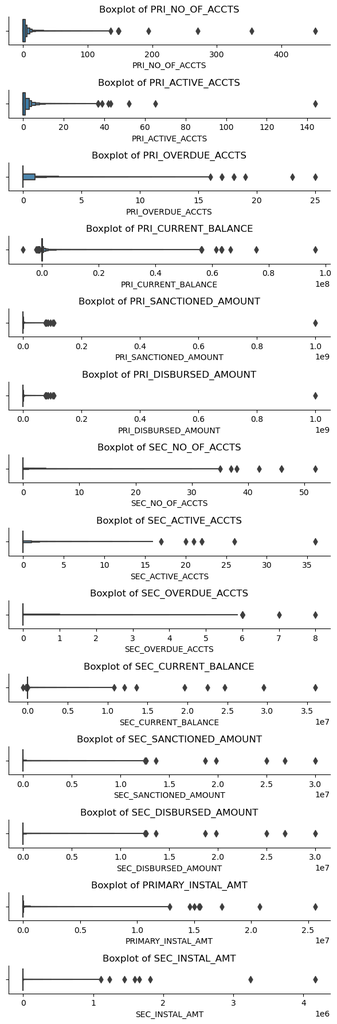

```python
columns =['disbursed_amount','asset_cost','ltv','NEW_ACCTS_IN_LAST_SIX_MONTHS','DELINQUENT_ACCTS_IN_LAST_SIX_MONTHS',
          'AVERAGE_ACCT_AGE','CREDIT_HISTORY_LENGTH','NO_OF_INQUIRIES','Age',]
#for col in loan.columns:
#       if pd.api.types.is_numeric_dtype(loan[col]):
#            columns.append(col)
fig,ax = plt.subplots(len(loan_pri_sec_acc),layout = "tight" , figsize=(6, 18))
plt.subplots_adjust(hspace=4)  # Adjust the vertical spacing
#print(columns)
for col ,ax in zip(loan_pri_sec_acc,ax.flat):
    sns.boxenplot(data=loan,x=col,ax=ax) ;
    sns.despine();
    ax.set_title("Boxplot of " + col)
    # Use this command to enable the scrolling for outputs in the notebook
display(HTML("<style>div.output_scroll { height: auto; }</style>"))
```

#### Let's check the histogram

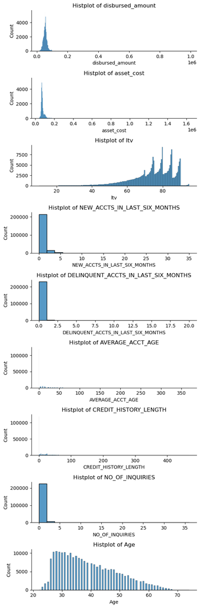

```python
#columns =['disbursed_amount','asset_cost','ltv','NEW_ACCTS_IN_LAST_SIX_MONTHS','DELINQUENT_ACCTS_IN_LAST_SIX_MONTHS',
#          'AVERAGE_ACCT_AGE','CREDIT_HISTORY_LENGTH','NO_OF_INQUIRIES','Age',]
#for col in loan.columns:
#       if pd.api.types.is_numeric_dtype(loan[col]):
#            columns.append(col)
fig,ax = plt.subplots(len(columns),layout = "tight" , figsize=(6, 18))
plt.subplots_adjust(hspace=1)  # Adjust the vertical spacing
#print(columns)
for col ,ax in zip(columns,ax.flat):
    sns.histplot(data=loan,x=col,ax=ax) ;
    sns.despine();
    ax.set_title("Histplot of " + col)
```

```python
loan_pri_sec_acc = ['PRI_NO_OF_ACCTS' , 'PRI_ACTIVE_ACCTS' , 'PRI_OVERDUE_ACCTS' , 'PRI_CURRENT_BALANCE',
                    'PRI_SANCTIONED_AMOUNT','PRI_DISBURSED_AMOUNT' ,'SEC_NO_OF_ACCTS','SEC_ACTIVE_ACCTS',
                    'SEC_OVERDUE_ACCTS','SEC_CURRENT_BALANCE','SEC_SANCTIONED_AMOUNT',
                    'SEC_DISBURSED_AMOUNT','PRIMARY_INSTAL_AMT','SEC_INSTAL_AMT']
other_columns= ['disbursed_amount','asset_cost','ltv','PERFORM_CNS_SCORE','NEW_ACCTS_IN_LAST_SIX_MONTHS',
                    'DELINQUENT_ACCTS_IN_LAST_SIX_MONTHS','AVERAGE_ACCT_AGE','CREDIT_HISTORY_LENGTH','DisbursalTime',
                    'NO_OF_INQUIRIES','Age']

loan.iloc[:,21:34].describe()
```

|  | PRI_NO_OF_ACCTS | PRI_ACTIVE_ACCTS | PRI_OVERDUE_ACCTS | PRI_CURRENT_BALANCE | PRI_SANCTIONED_AMOUNT | PRI_DISBURSED_AMOUNT | SEC_NO_OF_ACCTS | SEC_ACTIVE_ACCTS | SEC_OVERDUE_ACCTS | SEC_CURRENT_BALANCE | SEC_SANCTIONED_AMOUNT | SEC_DISBURSED_AMOUNT | PRIMARY_INSTAL_AMT |
| --- | --- | --- | --- | --- | --- | --- | --- | --- | --- | --- | --- | --- | --- |
| count | 233154.000000 | 233154.000000 | 233154.000000 | 2.331540e+05 | 2.331540e+05 | 2.331540e+05 | 233154.000000 | 233154.000000 | 233154.000000 | 2.331540e+05 | 2.331540e+05 | 2.331540e+05 | 2.331540e+05 |
| mean | 2.440636 | 1.039896 | 0.156549 | 1.659001e+05 | 2.185039e+05 | 2.180659e+05 | 0.059081 | 0.027703 | 0.007244 | 5.427793e+03 | 7.295923e+03 | 7.179998e+03 | 1.310548e+04 |
| std | 5.217233 | 1.941496 | 0.548787 | 9.422736e+05 | 2.374794e+06 | 2.377744e+06 | 0.626795 | 0.316057 | 0.111079 | 1.702370e+05 | 1.831560e+05 | 1.825925e+05 | 1.513679e+05 |
| min | 0.000000 | 0.000000 | 0.000000 | -6.678296e+06 | 0.000000e+00 | 0.000000e+00 | 0.000000 | 0.000000 | 0.000000 | -5.746470e+05 | 0.000000e+00 | 0.000000e+00 | 0.000000e+00 |
| 25% | 0.000000 | 0.000000 | 0.000000 | 0.000000e+00 | 0.000000e+00 | 0.000000e+00 | 0.000000 | 0.000000 | 0.000000 | 0.000000e+00 | 0.000000e+00 | 0.000000e+00 | 0.000000e+00 |
| 50% | 0.000000 | 0.000000 | 0.000000 | 0.000000e+00 | 0.000000e+00 | 0.000000e+00 | 0.000000 | 0.000000 | 0.000000 | 0.000000e+00 | 0.000000e+00 | 0.000000e+00 | 0.000000e+00 |
| 75% | 3.000000 | 1.000000 | 0.000000 | 3.500650e+04 | 6.250000e+04 | 6.080000e+04 | 0.000000 | 0.000000 | 0.000000 | 0.000000e+00 | 0.000000e+00 | 0.000000e+00 | 1.999000e+03 |
| max | 453.000000 | 144.000000 | 25.000000 | 9.652492e+07 | 1.000000e+09 | 1.000000e+09 | 52.000000 | 36.000000 | 8.000000 | 3.603285e+07 | 3.000000e+07 | 3.000000e+07 | 2.564281e+07 |

##### First I start with Primary, Secondary account columns

```python
outlier_boundaries = {}
number_of_rows = loan.shape[0]

for col in loan_pri_sec_acc:
    Q25, Q50, Q75 = np.percentile(loan[col] , (25,50,75))
    IQR = Q75 - Q25
    lower_bound = Q25 - 1.5 * IQR
    upper_bound = Q75 + 1.5 * IQR
    outlier_boundaries[col] = (lower_bound, upper_bound)

    number_of_outliers =  len(  loan[ (loan[col]> upper_bound) | (loan[col]<lower_bound) ]  )
    percentage_of_outliers =  round( ((number_of_outliers/number_of_rows) * 100 ),2)
    print ("Columnn {}: The number of outliers is: {}, and the percentage is {}%" .format(col,number_of_outliers,percentage_of_outliers))
```

```
Columnn PRI_NO_OF_ACCTS: The number of outliers is: 21914, and the percentage is 9.4%
Columnn PRI_ACTIVE_ACCTS: The number of outliers is: 32534, and the percentage is 13.95%
Columnn PRI_OVERDUE_ACCTS: The number of outliers is: 26275, and the percentage is 11.27%
Columnn PRI_CURRENT_BALANCE: The number of outliers is: 41044, and the percentage is 17.6%
Columnn PRI_SANCTIONED_AMOUNT: The number of outliers is: 39587, and the percentage is 16.98%
Columnn PRI_DISBURSED_AMOUNT: The number of outliers is: 39712, and the percentage is 17.03%
Columnn SEC_NO_OF_ACCTS: The number of outliers is: 5865, and the percentage is 2.52%
Columnn SEC_ACTIVE_ACCTS: The number of outliers is: 3817, and the percentage is 1.64%
Columnn SEC_OVERDUE_ACCTS: The number of outliers is: 1337, and the percentage is 0.57%
Columnn SEC_CURRENT_BALANCE: The number of outliers is: 3364, and the percentage is 1.44%
Columnn SEC_SANCTIONED_AMOUNT: The number of outliers is: 3736, and the percentage is 1.6%
Columnn SEC_DISBURSED_AMOUNT: The number of outliers is: 3704, and the percentage is 1.59%
Columnn PRIMARY_INSTAL_AMT: The number of outliers is: 38868, and the percentage is 16.67%
Columnn SEC_INSTAL_AMT: The number of outliers is: 2217, and the percentage is 0.95%
```

>> For variables with an outlier percentage of less than 15%, I utilize the capping method.  
>> For variables with an outlier percentage greater than 15%, I utilize log transformation. Due to the high number of zeros, I employ the log-plus-one transformation method.

```python
less_outlier_columns = ['PRI_NO_OF_ACCTS' , 'PRI_ACTIVE_ACCTS','PRI_OVERDUE_ACCTS','SEC_NO_OF_ACCTS','SEC_ACTIVE_ACCTS'
                       ,'SEC_OVERDUE_ACCTS' , 'SEC_CURRENT_BALANCE','SEC_SANCTIONED_AMOUNT','SEC_DISBURSED_AMOUNT','SEC_INSTAL_AMT']
high_outlier_columns = ['PRI_CURRENT_BALANCE','PRI_SANCTIONED_AMOUNT' ,'PRI_DISBURSED_AMOUNT','PRIMARY_INSTAL_AMT']
```

##### For Less than 15% - First I check some specific percentiles

```python
# less_outlier_columns

# Describe the selected columns and store it in a DataFrame
#quantiles = loan[less_outlier_columns].describe()

# Create a custom DataFrame with q1 and q5 added as rows
custom_description = pd.DataFrame()

# Calculate q1 and q5 for each column and add them to the custom_description DataFrame
for col in less_outlier_columns:
    quantiles = loan[col].describe()
    q1,q5,q10,q25,q50,q70,q75,q90,q95,q99 = np.percentile(loan[col], (1,5,10,25,50,70,75,90,95,99))
    iqr = q75 - q25
    custom_description[col] = quantiles
    custom_description.at['q1', col] = q1
    custom_description.at['q5', col] = q5
    custom_description.at['q10', col] = q10
    custom_description.at['q25', col] = q25
    custom_description.at['q50', col] = q50
    custom_description.at['q70', col] = q70
    custom_description.at['q90', col] = q90
    custom_description.at['q95', col] = q95
    custom_description.at['q99', col] = q99
    custom_description.at['iqr', col] = iqr

# Print the custom description
custom_description
```

|  | PRI_NO_OF_ACCTS | PRI_ACTIVE_ACCTS | PRI_OVERDUE_ACCTS | SEC_NO_OF_ACCTS | SEC_ACTIVE_ACCTS | SEC_OVERDUE_ACCTS | SEC_CURRENT_BALANCE | SEC_SANCTIONED_AMOUNT | SEC_DISBURSED_AMOUNT | SEC_INSTAL_AMT |
| --- | --- | --- | --- | --- | --- | --- | --- | --- | --- | --- |
| count | 233154.000000 | 233154.000000 | 233154.000000 | 233154.000000 | 233154.000000 | 233154.000000 | 2.331540e+05 | 2.331540e+05 | 2.331540e+05 | 2.331540e+05 |
| mean | 2.440636 | 1.039896 | 0.156549 | 0.059081 | 0.027703 | 0.007244 | 5.427793e+03 | 7.295923e+03 | 7.179998e+03 | 3.232684e+02 |
| std | 5.217233 | 1.941496 | 0.548787 | 0.626795 | 0.316057 | 0.111079 | 1.702370e+05 | 1.831560e+05 | 1.825925e+05 | 1.555369e+04 |
| min | 0.000000 | 0.000000 | 0.000000 | 0.000000 | 0.000000 | 0.000000 | -5.746470e+05 | 0.000000e+00 | 0.000000e+00 | 0.000000e+00 |
| 25% | 0.000000 | 0.000000 | 0.000000 | 0.000000 | 0.000000 | 0.000000 | 0.000000e+00 | 0.000000e+00 | 0.000000e+00 | 0.000000e+00 |
| 50% | 0.000000 | 0.000000 | 0.000000 | 0.000000 | 0.000000 | 0.000000 | 0.000000e+00 | 0.000000e+00 | 0.000000e+00 | 0.000000e+00 |
| 75% | 3.000000 | 1.000000 | 0.000000 | 0.000000 | 0.000000 | 0.000000 | 0.000000e+00 | 0.000000e+00 | 0.000000e+00 | 0.000000e+00 |
| max | 453.000000 | 144.000000 | 25.000000 | 52.000000 | 36.000000 | 8.000000 | 3.603285e+07 | 3.000000e+07 | 3.000000e+07 | 4.170901e+06 |
| q1 | 0.000000 | 0.000000 | 0.000000 | 0.000000 | 0.000000 | 0.000000 | 0.000000e+00 | 0.000000e+00 | 0.000000e+00 | 0.000000e+00 |
| q5 | 0.000000 | 0.000000 | 0.000000 | 0.000000 | 0.000000 | 0.000000 | 0.000000e+00 | 0.000000e+00 | 0.000000e+00 | 0.000000e+00 |
| q10 | 0.000000 | 0.000000 | 0.000000 | 0.000000 | 0.000000 | 0.000000 | 0.000000e+00 | 0.000000e+00 | 0.000000e+00 | 0.000000e+00 |
| q25 | 0.000000 | 0.000000 | 0.000000 | 0.000000 | 0.000000 | 0.000000 | 0.000000e+00 | 0.000000e+00 | 0.000000e+00 | 0.000000e+00 |
| q50 | 0.000000 | 0.000000 | 0.000000 | 0.000000 | 0.000000 | 0.000000 | 0.000000e+00 | 0.000000e+00 | 0.000000e+00 | 0.000000e+00 |
| q70 | 2.000000 | 1.000000 | 0.000000 | 0.000000 | 0.000000 | 0.000000 | 0.000000e+00 | 0.000000e+00 | 0.000000e+00 | 0.000000e+00 |
| q90 | 7.000000 | 3.000000 | 1.000000 | 0.000000 | 0.000000 | 0.000000 | 0.000000e+00 | 0.000000e+00 | 0.000000e+00 | 0.000000e+00 |
| q95 | 11.000000 | 5.000000 | 1.000000 | 0.000000 | 0.000000 | 0.000000 | 0.000000e+00 | 0.000000e+00 | 0.000000e+00 | 0.000000e+00 |
| q99 | 23.000000 | 9.000000 | 2.000000 | 2.000000 | 1.000000 | 0.000000 | 1.973378e+04 | 5.000000e+04 | 4.754483e+04 | 0.000000e+00 |
| iqr | 3.000000 | 1.000000 | 0.000000 | 0.000000 | 0.000000 | 0.000000 | 0.000000e+00 | 0.000000e+00 | 0.000000e+00 | 0.000000e+00 |

```python
print("Based on the above data summary: ")
print("PRI_NO_OF_ACCTS   : Sharp increase from the 95th percentile (11) to the 99th percentile (23). Capping value : 11 ")
print("PRI_ACTIVE_ACCTS  : Sharp increase from the 95th percentile (5) to the 99th percentile (9). Capping value : 5 ")
print("PRI_OVERDUE_ACCTS : The data increases from 1 at the 90th percentile to 2 at the 99th percentile. Capping value : 1")
print("\nI will remove these columns-before running the model- due to hight number of zero. Given that I am using logistic regression,columns with a high proportion \
of constant values (like zeros in this case) are less likely to contribute meaningful information to the model.")
print("SEC_NO_OF_ACCTS: The 95th percentile is 0, which means 95% of the values are zero.")
print("SEC_ACTIVE_ACCTS: 95% of the values are zero.")
print("SEC_OVERDUE_ACCTS: More than 95% of the values are zero.")
print("SEC_SANCTIONED_AMOUNT: Even though the 99th percentile has a value, 90% of the data is zero.")
print("SEC_DISBURSED_AMOUNT: Similar to the sanctioned amount, 90% of the data is zero.")
print("SEC_INSTAL_AMT: 99% of the values are zero.")
```

```
Based on the above data summary:
PRI_NO_OF_ACCTS   : Sharp increase from the 95th percentile (11) to the 99th percentile (23). Capping value : 11
PRI_ACTIVE_ACCTS  : Sharp increase from the 95th percentile (5) to the 99th percentile (9). Capping value : 5
PRI_OVERDUE_ACCTS : The data increases from 1 at the 90th percentile to 2 at the 99th percentile. Capping value : 1

I will remove these columns-before running the model- due to hight number of zero. Given that I am using logistic regression,columns with a high proportion of constant values (like zeros in this case) are less likely to contribute meaningful information to the model.
SEC_NO_OF_ACCTS: The 95th percentile is 0, which means 95% of the values are zero.
SEC_ACTIVE_ACCTS: 95% of the values are zero.
SEC_OVERDUE_ACCTS: More than 95% of the values are zero.
SEC_SANCTIONED_AMOUNT: Even though the 99th percentile has a value, 90% of the data is zero.
SEC_DISBURSED_AMOUNT: Similar to the sanctioned amount, 90% of the data is zero.
SEC_INSTAL_AMT: 99% of the values are zero.
```

```python
loan.PRI_NO_OF_ACCTS = np.where(loan.PRI_NO_OF_ACCTS > 11 , 11 , loan.PRI_NO_OF_ACCTS  )
loan.PRI_ACTIVE_ACCTS   = np.where(loan.PRI_ACTIVE_ACCTS   > 5 , 5 , loan.PRI_ACTIVE_ACCTS    )
loan.PRI_OVERDUE_ACCTS  = np.where(loan.PRI_OVERDUE_ACCTS  > 1 , 1 , loan.PRI_OVERDUE_ACCTS   )
skewness_data = loan[less_outlier_columns].skew()
print(skewness_data)
print("The skewness for those three columns has decreased; the other columns will be removed later.")
```

```
PRI_NO_OF_ACCTS            1.735229
PRI_ACTIVE_ACCTS           1.620500
PRI_OVERDUE_ACCTS          2.449631
SEC_NO_OF_ACCTS           27.986090
SEC_ACTIVE_ACCTS          30.599510
SEC_OVERDUE_ACCTS         24.129271
SEC_CURRENT_BALANCE      108.506295
SEC_SANCTIONED_AMOUNT     75.254932
SEC_DISBURSED_AMOUNT      75.764252
SEC_INSTAL_AMT           153.806369
dtype: float64
The skewness for those three columns has decreased; the other columns will be removed later.
```

##### For more than 15% - First I check the skewness

```python
# Plot histograms for columns with more than 15% outliers  - high_outlier_columns
#plt.figure(figsize=(15, 20))

#for i, col in enumerate(high_outlier_percentage, 1):
#    plt.subplot(5, 3, i)
#    sns.histplot(loan.sample(30000, random_state=42)[col], kde=True)
#    plt.title(f'Histogram for {col}')
#    plt.xlabel(col)
#    plt.ylabel('Frequency')

#plt.tight_layout()
#plt.show()

print("It takes a lot to plot the distribution, so to see the skewness I used the skew function.")
skewness_data = loan[high_outlier_columns].skew()
print(skewness_data)
print("\n Since the data is highly skewed, I will use log transformation to handle positive skewness, we have a lot of 0.\
 So, I use log-plus-one transformation.")

print("For the PRI_CURRENT_BALANCE_shifted we have some negative values, so we need to shift the data first.")
shift_value = abs(loan['PRI_CURRENT_BALANCE'].min()) + 1
loan['PRI_CURRENT_BALANCE'] = loan['PRI_CURRENT_BALANCE'] + shift_value

# Apply the transformation
for col in high_outlier_columns:
    loan[col] = np.log1p(loan[col])

skewness_data = loan[high_outlier_columns].skew()
print("\nThe skewness after the transformation:")
print(skewness_data)

print("\nThe transformed PRI_CURRENT_BALANCE data is now concentrated around a specific value-the original data had a lot of zeros-, with the 25th, 50th (median), and 75th percentiles all being very close to each other (around 15.714 to 15.720). This suggests that a significant portion of the data is clustered around this range.")
print(loan.PRI_CURRENT_BALANCE.describe()  )
```

```
It takes a lot to plot the distribution, so to see the skewness I used the skew function.
PRI_CURRENT_BALANCE       29.425813
PRI_SANCTIONED_AMOUNT    323.697212
PRI_DISBURSED_AMOUNT     322.541495
PRIMARY_INSTAL_AMT        69.916156
dtype: float64

 Since the data is highly skewed, I will use log transformation to handle positive skewness, we have a lot of 0. So, I use log-plus-one transformation.
For the PRI_CURRENT_BALANCE_shifted we have some negative values, so we need to shift the data first.

The skewness after the transformation:
PRI_CURRENT_BALANCE     -16.728728
PRI_SANCTIONED_AMOUNT     0.481521
PRI_DISBURSED_AMOUNT      0.487272
PRIMARY_INSTAL_AMT        0.940679
dtype: float64

The transformed PRI_CURRENT_BALANCE data is now concentrated around a specific value-the original data had a lot of zeros-, with the 25th, 50th (median), and 75th percentiles all being very close to each other (around 15.714 to 15.720). This suggests that a significant portion of the data is cluster…
count    233154.000000
mean         15.734689
std           0.084498
min           0.693147
25%          15.714374
50%          15.714374
75%          15.719602
max          18.452211
Name: PRI_CURRENT_BALANCE, dtype: float64
```

```python
print(loan['PRI_CURRENT_BALANCE'].unique())
```

```
[15.71437372 15.84647733 15.89367078 ... 18.45221059 17.215544
 17.72498372]
```

```python
custom_description = pd.DataFrame()

# Calculate q1 and q5 for each column and add them to the custom_description DataFrame
for col in other_columns:
    quantiles = loan[col].describe()
    q1,q5,q10,q25,q50,q70,q75,q90,q95,q99 = np.percentile(loan[col], (1,5,10,25,50,70,75,90,95,99))
    iqr = q75 - q25
    custom_description[col] = quantiles
    custom_description.at['q1', col] = q1
    custom_description.at['q5', col] = q5
    custom_description.at['q10', col] = q10
    custom_description.at['q25', col] = q25
    custom_description.at['q50', col] = q50
    custom_description.at['q70', col] = q70
    custom_description.at['q90', col] = q90
    custom_description.at['q95', col] = q95
    custom_description.at['q99', col] = q99
    custom_description.at['iqr', col] = iqr

# Print the custom description
display(custom_description)
#display(loan[other_columns].describe())
display(loan[other_columns].skew())
outlier_boundaries = {}
number_of_rows = loan.shape[0]

for col in other_columns:
    Q25, Q50, Q75 = np.percentile(loan[col] , (25,50,75))
    IQR = Q75 - Q25
    lower_bound = Q25 - 1.5 * IQR
    upper_bound = Q75 + 1.5 * IQR
    outlier_boundaries[col] = (lower_bound, upper_bound)

    number_of_outliers =  len(  loan[ (loan[col]> upper_bound) | (loan[col]<lower_bound) ]  )
    percentage_of_outliers =  round( ((number_of_outliers/number_of_rows) * 100 ),2)
    print ("Columnn {}: The number of outliers is: {}, and the percentage is {}%" .format(col,number_of_outliers,percentage_of_outliers))
```

|  | disbursed_amount | asset_cost | ltv | PERFORM_CNS_SCORE | NEW_ACCTS_IN_LAST_SIX_MONTHS | DELINQUENT_ACCTS_IN_LAST_SIX_MONTHS | AVERAGE_ACCT_AGE | CREDIT_HISTORY_LENGTH | DisbursalTime | NO_OF_INQUIRIES | Age |
| --- | --- | --- | --- | --- | --- | --- | --- | --- | --- | --- | --- |
| count | 233154.000000 | 2.331540e+05 | 233154.000000 | 233154.000000 | 233154.000000 | 233154.000000 | 233154.000000 | 233154.000000 | 233154.000000 | 233154.000000 | 233154.000000 |
| mean | 54356.993528 | 7.586507e+04 | 74.746530 | 289.462994 | 0.381833 | 0.097481 | 8.915764 | 16.252404 | 4.726524 | 0.206615 | 38.988578 |
| std | 12971.314171 | 1.894478e+04 | 11.456636 | 338.374779 | 0.955107 | 0.384439 | 15.106416 | 28.581255 | 0.445744 | 0.706498 | 9.817313 |
| min | 13320.000000 | 3.700000e+04 | 10.030000 | 0.000000 | 0.000000 | 0.000000 | 0.000000 | 0.000000 | 4.000000 | 0.000000 | 22.000000 |
| 25% | 47145.000000 | 6.571700e+04 | 68.880000 | 0.000000 | 0.000000 | 0.000000 | 0.000000 | 0.000000 | 4.000000 | 0.000000 | 31.000000 |
| 50% | 53803.000000 | 7.094600e+04 | 76.800000 | 0.000000 | 0.000000 | 0.000000 | 0.000000 | 0.000000 | 5.000000 | 0.000000 | 37.000000 |
| 75% | 60413.000000 | 7.920175e+04 | 83.670000 | 678.000000 | 0.000000 | 0.000000 | 13.000000 | 24.000000 | 5.000000 | 0.000000 | 46.000000 |
| max | 990572.000000 | 1.628992e+06 | 95.000000 | 890.000000 | 35.000000 | 20.000000 | 369.000000 | 468.000000 | 5.000000 | 36.000000 | 74.000000 |
| q1 | 26529.000000 | 4.709953e+04 | 39.250000 | 0.000000 | 0.000000 | 0.000000 | 0.000000 | 0.000000 | 4.000000 | 0.000000 | 24.000000 |
| q5 | 34939.000000 | 5.826400e+04 | 52.310000 | 0.000000 | 0.000000 | 0.000000 | 0.000000 | 0.000000 | 4.000000 | 0.000000 | 26.000000 |
| q10 | 39794.000000 | 6.133000e+04 | 58.860000 | 0.000000 | 0.000000 | 0.000000 | 0.000000 | 0.000000 | 4.000000 | 0.000000 | 27.000000 |
| q25 | 47145.000000 | 6.571700e+04 | 68.880000 | 0.000000 | 0.000000 | 0.000000 | 0.000000 | 0.000000 | 4.000000 | 0.000000 | 31.000000 |
| q50 | 53803.000000 | 7.094600e+04 | 76.800000 | 0.000000 | 0.000000 | 0.000000 | 0.000000 | 0.000000 | 5.000000 | 0.000000 | 37.000000 |
| q70 | 58759.000000 | 7.680700e+04 | 82.010000 | 627.000000 | 0.000000 | 0.000000 | 11.000000 | 18.000000 | 5.000000 | 0.000000 | 44.000000 |
| q90 | 68882.000000 | 9.914000e+04 | 87.950000 | 761.000000 | 1.000000 | 0.000000 | 26.000000 | 48.000000 | 5.000000 | 1.000000 | 53.000000 |
| q95 | 74122.350000 | 1.096800e+05 | 89.380000 | 825.000000 | 2.000000 | 1.000000 | 38.000000 | 72.000000 | 5.000000 | 1.000000 | 58.000000 |
| q99 | 95391.000000 | 1.560160e+05 | 89.950000 | 836.000000 | 4.000000 | 2.000000 | 68.000000 | 140.000000 | 5.000000 | 3.000000 | 63.000000 |
| iqr | 13268.000000 | 1.348475e+04 | 14.790000 | 678.000000 | 0.000000 | 0.000000 | 13.000000 | 24.000000 | 1.000000 | 0.000000 | 15.000000 |

```
disbursed_amount                       4.492240
asset_cost                             6.133485
ltv                                   -1.075766
PERFORM_CNS_SCORE                      0.445150
NEW_ACCTS_IN_LAST_SIX_MONTHS           4.839326
DELINQUENT_ACCTS_IN_LAST_SIX_MONTHS    6.641996
AVERAGE_ACCT_AGE                       3.285142
CREDIT_HISTORY_LENGTH                  2.969155
DisbursalTime                         -1.016395
NO_OF_INQUIRIES                        7.870683
Age                                    0.609162
dtype: float64
```

```
Columnn disbursed_amount: The number of outliers is: 9868, and the percentage is 4.23%
Columnn asset_cost: The number of outliers is: 24388, and the percentage is 10.46%
Columnn ltv: The number of outliers is: 6170, and the percentage is 2.65%
Columnn PERFORM_CNS_SCORE: The number of outliers is: 0, and the percentage is 0.0%
Columnn NEW_ACCTS_IN_LAST_SIX_MONTHS: The number of outliers is: 51660, and the percentage is 22.16%
Columnn DELINQUENT_ACCTS_IN_LAST_SIX_MONTHS: The number of outliers is: 18195, and the percentage is 7.8%
Columnn AVERAGE_ACCT_AGE: The number of outliers is: 15924, and the percentage is 6.83%
Columnn CREDIT_HISTORY_LENGTH: The number of outliers is: 16056, and the percentage is 6.89%
Columnn DisbursalTime: The number of outliers is: 0, and the percentage is 0.0%
Columnn NO_OF_INQUIRIES: The number of outliers is: 31193, and the percentage is 13.38%
Columnn Age: The number of outliers is: 16, and the percentage is 0.01%
```

<<<<<<<<<< Here is a summary and my approach for outlier treatment on the remaining columns: >>>>>>>>>>

**disbursed_amount:**  
Skewness: 4.49  
Outliers: 4.23%  
Approach: Moderate skewness and low outlier percentage. I will utilize capping based on percentiles.

**asset_cost:**  
Skewness: 6.13  
Outliers: 10.46%  
Approach: High skewness and moderate outlier percentage. Log transformation can be considered, or capping can be applied.

**ltv:**  
Skewness: -1.08  
Outliers: 2.65%  
Approach: Negative skewness indicates left skewness. I will keep the values as is.

**PERFORM_CNS_SCORE:**  
Skewness: 0.44  
Outliers: 0%  
Approach: Relatively low skewness and no outliers. I will keep this column as it is.

**NEW_ACCTS_IN_LAST_SIX_MONTHS:**  
Skewness: 4.84  
Outliers: 22.16%  
Approach: High skewness and a significant outlier percentage. Log transformation can be considered. We have a lot of 0. So, I use log-plus-one transformation.

**DELINQUENT_ACCTS_IN_LAST_SIX_MONTHS:**  
Skewness: 6.64  
Outliers: 7.8%  
Approach: High skewness. Log transformation can be considered, or capping can be applied.

**AVERAGE_ACCT_AGE:**  
Skewness: 3.29  
Outliers: 6.83%  
Approach: Moderate skewness. I will use capping or log transformation.

**CREDIT_HISTORY_LENGTH:**  
Skewness: 2.97  
Outliers: 6.89%  
Approach: Moderate skewness. Consider capping or log transformation.

**NO_OF_INQUIRIES:**  
Skewness: 7.87  
Outliers: 13.38%  
Approach: High skewness and moderate outlier percentage. Log transformation can be considered.

**Age:**  
Skewness: 0.61  
Outliers: 0.01%  
Approach: Relatively low skewness and very few outliers. I will keep this column as it is.

To summarize:

For columns with high skewness (>2 or <-2) and a significant percentage of outliers, I consider log transformation.

For columns with moderate skewness and outliers, I consider capping based on percentiles.

For columns with low skewness and outliers, I keep them as they are.

```python
columns_for_capping_treatment = { 'disbursed_amount' :74122 ,'AVERAGE_ACCT_AGE' :68 ,'CREDIT_HISTORY_LENGTH' :140 }
# Uppdating values upper than Cap Value
for col,cap_value in columns_for_capping_treatment.items():
    loan[col] = np.where(loan[col] > cap_value , cap_value , loan[col]  )

# I use  Log_plus_one, due to high number of zeros.
columns_for_log_treatment = ['asset_cost','NEW_ACCTS_IN_LAST_SIX_MONTHS','DELINQUENT_ACCTS_IN_LAST_SIX_MONTHS','NO_OF_INQUIRIES']
for col in columns_for_log_treatment:
    loan[col] = np.log1p(loan[col])
```

```python
custom_description = pd.DataFrame()

# Calculate q1 and q5 for each column and add them to the custom_description DataFrame
for col in other_columns:
    quantiles = loan[col].describe()
    q1,q5,q10,q25,q50,q70,q75,q90,q95,q99 = np.percentile(loan[col], (1,5,10,25,50,70,75,90,95,99))
    iqr = q75 - q25
    custom_description[col] = quantiles
    custom_description.at['q1', col] = q1
    custom_description.at['q5', col] = q5
    custom_description.at['q10', col] = q10
    custom_description.at['q25', col] = q25
    custom_description.at['q50', col] = q50
    custom_description.at['q70', col] = q70
    custom_description.at['q90', col] = q90
    custom_description.at['q95', col] = q95
    custom_description.at['q99', col] = q99
    custom_description.at['iqr', col] = iqr

# Print the custom description
display(custom_description)
#display(loan[other_columns].describe())
display(loan[other_columns].skew())
outlier_boundaries = {}
number_of_rows = loan.shape[0]

for col in other_columns:
    Q25, Q50, Q75 = np.percentile(loan[col] , (25,50,75))
    IQR = Q75 - Q25
    lower_bound = Q25 - 1.5 * IQR
    upper_bound = Q75 + 1.5 * IQR
    outlier_boundaries[col] = (lower_bound, upper_bound)

    number_of_outliers =  len(  loan[ (loan[col]> upper_bound) | (loan[col]<lower_bound) ]  )
    percentage_of_outliers =  round( ((number_of_outliers/number_of_rows) * 100 ),2)
    print ("Columnn {}: The number of outliers is: {}, and the percentage is {}%" .format(col,number_of_outliers,percentage_of_outliers))
```

|  | disbursed_amount | asset_cost | ltv | PERFORM_CNS_SCORE | NEW_ACCTS_IN_LAST_SIX_MONTHS | DELINQUENT_ACCTS_IN_LAST_SIX_MONTHS | AVERAGE_ACCT_AGE | CREDIT_HISTORY_LENGTH | DisbursalTime | NO_OF_INQUIRIES | Age |
| --- | --- | --- | --- | --- | --- | --- | --- | --- | --- | --- | --- |
| count | 233154.000000 | 233154.000000 | 233154.000000 | 233154.000000 | 233154.000000 | 233154.000000 | 233154.000000 | 233154.000000 | 233154.000000 | 233154.000000 | 233154.000000 |
| mean | 53717.306180 | 11.213166 | 74.746530 | 289.462994 | 0.205377 | 0.061115 | 8.663081 | 15.986061 | 4.726524 | 0.115941 | 38.988578 |
| std | 10844.110749 | 0.206688 | 11.456636 | 338.374779 | 0.418990 | 0.218191 | 13.605073 | 27.085072 | 0.445744 | 0.317679 | 9.817313 |
| min | 13320.000000 | 10.518700 | 10.030000 | 0.000000 | 0.000000 | 0.000000 | 0.000000 | 0.000000 | 4.000000 | 0.000000 | 22.000000 |
| 25% | 47145.000000 | 11.093128 | 68.880000 | 0.000000 | 0.000000 | 0.000000 | 0.000000 | 0.000000 | 4.000000 | 0.000000 | 31.000000 |
| 50% | 53803.000000 | 11.169688 | 76.800000 | 0.000000 | 0.000000 | 0.000000 | 0.000000 | 0.000000 | 5.000000 | 0.000000 | 37.000000 |
| 75% | 60413.000000 | 11.279766 | 83.670000 | 678.000000 | 0.000000 | 0.000000 | 13.000000 | 24.000000 | 5.000000 | 0.000000 | 46.000000 |
| max | 74122.000000 | 14.303473 | 95.000000 | 890.000000 | 3.583519 | 3.044522 | 68.000000 | 140.000000 | 5.000000 | 3.610918 | 74.000000 |
| q1 | 26529.000000 | 10.760040 | 39.250000 | 0.000000 | 0.000000 | 0.000000 | 0.000000 | 0.000000 | 4.000000 | 0.000000 | 24.000000 |
| q5 | 34939.000000 | 10.972757 | 52.310000 | 0.000000 | 0.000000 | 0.000000 | 0.000000 | 0.000000 | 4.000000 | 0.000000 | 26.000000 |
| q10 | 39794.000000 | 11.024041 | 58.860000 | 0.000000 | 0.000000 | 0.000000 | 0.000000 | 0.000000 | 4.000000 | 0.000000 | 27.000000 |
| q25 | 47145.000000 | 11.093128 | 68.880000 | 0.000000 | 0.000000 | 0.000000 | 0.000000 | 0.000000 | 4.000000 | 0.000000 | 31.000000 |
| q50 | 53803.000000 | 11.169688 | 76.800000 | 0.000000 | 0.000000 | 0.000000 | 0.000000 | 0.000000 | 5.000000 | 0.000000 | 37.000000 |
| q70 | 58759.000000 | 11.249064 | 82.010000 | 627.000000 | 0.000000 | 0.000000 | 11.000000 | 18.000000 | 5.000000 | 0.000000 | 44.000000 |
| q90 | 68882.000000 | 11.504298 | 87.950000 | 761.000000 | 0.693147 | 0.000000 | 26.000000 | 48.000000 | 5.000000 | 0.693147 | 53.000000 |
| q95 | 74122.000000 | 11.605331 | 89.380000 | 825.000000 | 1.098612 | 0.693147 | 38.000000 | 72.000000 | 5.000000 | 0.693147 | 58.000000 |
| q99 | 74122.000000 | 11.957720 | 89.950000 | 836.000000 | 1.609438 | 1.098612 | 68.000000 | 140.000000 | 5.000000 | 1.386294 | 63.000000 |
| iqr | 13268.000000 | 0.186638 | 14.790000 | 678.000000 | 0.000000 | 0.000000 | 13.000000 | 24.000000 | 1.000000 | 0.000000 | 15.000000 |

```
disbursed_amount                      -0.171861
asset_cost                             1.279172
ltv                                   -1.075766
PERFORM_CNS_SCORE                      0.445150
NEW_ACCTS_IN_LAST_SIX_MONTHS           2.052650
DELINQUENT_ACCTS_IN_LAST_SIX_MONTHS    3.723389
AVERAGE_ACCT_AGE                       2.155461
CREDIT_HISTORY_LENGTH                  2.475342
DisbursalTime                         -1.016395
NO_OF_INQUIRIES                        3.007293
Age                                    0.609162
dtype: float64
```

```
Columnn disbursed_amount: The number of outliers is: 2620, and the percentage is 1.12%
Columnn asset_cost: The number of outliers is: 19687, and the percentage is 8.44%
Columnn ltv: The number of outliers is: 6170, and the percentage is 2.65%
Columnn PERFORM_CNS_SCORE: The number of outliers is: 0, and the percentage is 0.0%
Columnn NEW_ACCTS_IN_LAST_SIX_MONTHS: The number of outliers is: 51660, and the percentage is 22.16%
Columnn DELINQUENT_ACCTS_IN_LAST_SIX_MONTHS: The number of outliers is: 18195, and the percentage is 7.8%
Columnn AVERAGE_ACCT_AGE: The number of outliers is: 15924, and the percentage is 6.83%
Columnn CREDIT_HISTORY_LENGTH: The number of outliers is: 16056, and the percentage is 6.89%
Columnn DisbursalTime: The number of outliers is: 0, and the percentage is 0.0%
Columnn NO_OF_INQUIRIES: The number of outliers is: 31193, and the percentage is 13.38%
Columnn Age: The number of outliers is: 16, and the percentage is 0.01%
```

```python
loan['NEW_ACCTS_IN_LAST_SIX_MONTHS'] = np.where(loan['NEW_ACCTS_IN_LAST_SIX_MONTHS'] > 1.609438 , 1.609438 , loan['NEW_ACCTS_IN_LAST_SIX_MONTHS']  )
loan['NO_OF_INQUIRIES'] = np.where(loan['NO_OF_INQUIRIES'] > 1.386294 , 1.386294 , loan['NO_OF_INQUIRIES']  )
```

Performing EDA

```python
loan.describe()
```

|  | UniqueID | disbursed_amount | asset_cost | ltv | branch_id | supplier_id | manufacturer_id | Current_pincode_ID | State_ID | Employee_code_ID | ... | PRIMARY_INSTAL_AMT | SEC_INSTAL_AMT | NEW_ACCTS_IN_LAST_SIX_MONTHS | DELINQUENT_ACCTS_IN_LAST_SIX_MONTHS | AVERAGE_ACCT_AGE | CREDIT_HISTORY_LENGTH | NO_OF_INQUIRIES | loan_default | Age | DisbursalTime |
| --- | --- | --- | --- | --- | --- | --- | --- | --- | --- | --- | --- | --- | --- | --- | --- | --- | --- | --- | --- | --- | --- |
| count | 233154.000000 | 233154.000000 | 233154.000000 | 233154.000000 | 233154.000000 | 233154.000000 | 233154.000000 | 233154.000000 | 233154.000000 | 233154.000000 | ... | 233154.000000 | 2.331540e+05 | 233154.000000 | 233154.000000 | 233154.000000 | 233154.000000 | 233154.000000 | 233154.000000 | 233154.000000 | 233154.000000 |
| mean | 535917.573376 | 53717.306180 | 11.213166 | 74.746530 | 72.936094 | 19638.635035 | 69.028054 | 3396.880247 | 7.262243 | 1549.477148 | ... | 2.790456 | 3.232684e+02 | 0.202055 | 0.061115 | 8.663081 | 15.986061 | 0.112543 | 0.217071 | 38.988578 | 4.726524 |
| std | 68315.693711 | 10844.110749 | 0.206688 | 11.456636 | 69.834995 | 3491.949566 | 22.141304 | 2238.147502 | 4.482230 | 975.261278 | ... | 4.201328 | 1.555369e+04 | 0.405589 | 0.218191 | 13.605073 | 27.085072 | 0.300163 | 0.412252 | 9.817313 | 0.445744 |
| min | 417428.000000 | 13320.000000 | 10.518700 | 10.030000 | 1.000000 | 10524.000000 | 45.000000 | 1.000000 | 1.000000 | 1.000000 | ... | 0.000000 | 0.000000e+00 | 0.000000 | 0.000000 | 0.000000 | 0.000000 | 0.000000 | 0.000000 | 22.000000 | 4.000000 |
| 25% | 476786.250000 | 47145.000000 | 11.093128 | 68.880000 | 14.000000 | 16535.000000 | 48.000000 | 1511.000000 | 4.000000 | 713.000000 | ... | 0.000000 | 0.000000e+00 | 0.000000 | 0.000000 | 0.000000 | 0.000000 | 0.000000 | 0.000000 | 31.000000 | 4.000000 |
| 50% | 535978.500000 | 53803.000000 | 11.169688 | 76.800000 | 61.000000 | 20333.000000 | 86.000000 | 2970.000000 | 6.000000 | 1451.000000 | ... | 0.000000 | 0.000000e+00 | 0.000000 | 0.000000 | 0.000000 | 0.000000 | 0.000000 | 0.000000 | 37.000000 | 5.000000 |
| 75% | 595039.750000 | 60413.000000 | 11.279766 | 83.670000 | 130.000000 | 23000.000000 | 86.000000 | 5677.000000 | 10.000000 | 2362.000000 | ... | 7.600902 | 0.000000e+00 | 0.000000 | 0.000000 | 13.000000 | 24.000000 | 0.000000 | 0.000000 | 46.000000 | 5.000000 |
| max | 671084.000000 | 74122.000000 | 14.303473 | 95.000000 | 261.000000 | 24803.000000 | 156.000000 | 7345.000000 | 22.000000 | 3795.000000 | ... | 17.059774 | 4.170901e+06 | 1.609438 | 3.044522 | 68.000000 | 140.000000 | 1.386294 | 1.000000 | 74.000000 | 5.000000 |

8 rows × 39 columns

```python
loan.manufacturer_id.unique
```

```
<bound method Series.unique of 0         45
1         45
2         45
3         45
4         86
          ..
233149    51
233150    51
233151    45
233152    48
233153    45
Name: manufacturer_id, Length: 233154, dtype: int64>
```

-Provide the statistical description of the quantitative data variables

# Data Summary: The dataset contains a total of 233,154 records.

Asset Cost: The asset cost has a mean of approximately 75,865.07 and a standard deviation of approximately 18,944.78. The minimum asset cost is 37,000, and the maximum asset cost is 1,628,992.

Loan-to-Value Ratio (LTV): The LTV ratio has a mean of approximately 74.75, with a standard deviation of approximately 11.46. The LTV ratio ranges from a minimum of 10.03 to a maximum of 95.00.

New Accounts in Last Six Months: On average, there are 0.38 new accounts in the last six months, with a maximum of 35.

Delinquent Accounts in Last Six Months: On average, there are 0.097 delinquent accounts in the last six months, with a maximum of 20.

Average Account Age: The average account age ranges from 0 to 369 months, with a mean of approximately 8.92 months.

Credit History Length: Credit history length varies widely, with a mean of approximately 16.25 months and a maximum of 468 months.

Number of Inquiries: On average, there are 0.21 inquiries, with a maximum of 36.

Loan Default: The dataset indicates loan default, with 0 indicating non-default and 1 indicating default.

-Explain how is the target variable distributed overall

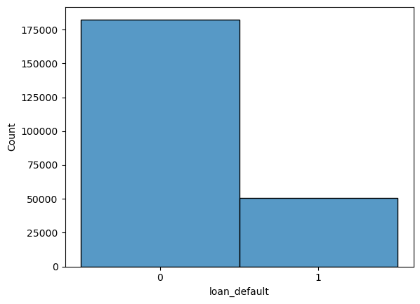

```
0    182543
1     50611
Name: loan_default, dtype: int64
Approximately 78.27% of the entries are 0 (no default).
Approximately 21.73% of the entries are 1 (defaulted).
So, the dataset is imbalanced with respect to the target variable loan_default
```

```python
colors = ["red" , "yellow"]
sns.histplot(loan , x=loan.loan_default , discrete = True , multiple='stack')
plt.xticks([0, 1])
plt.show()
print(loan.loan_default.value_counts())
print("Approximately 78.27% of the entries are 0 (no default).\nApproximately 21.73% of the entries are 1 (defaulted).")
print("So, the dataset is imbalanced with respect to the target variable loan_default")
```

Study the distribution of the target variable across various categories like branch, city, state, branch, supplier, manufacturer, etc.

#### First, I will plot the distribution. Then, I will calculate the rate for each category to see which items have a higher default rate

|  | branch_id | loan_default | count |
| --- | --- | --- | --- |
| 2 | 2 | 0 | 10683 |
| 60 | 67 | 0 | 9130 |
| 4 | 3 | 0 | 7616 |
| 6 | 5 | 0 | 7171 |
| 36 | 34 | 0 | 6375 |
| ... | ... | ... | ... |
| 141 | 217 | 1 | 45 |
| 163 | 261 | 1 | 39 |
| 85 | 84 | 1 | 31 |
| 101 | 111 | 1 | 20 |
| 127 | 158 | 1 | 19 |

164 rows × 3 columns

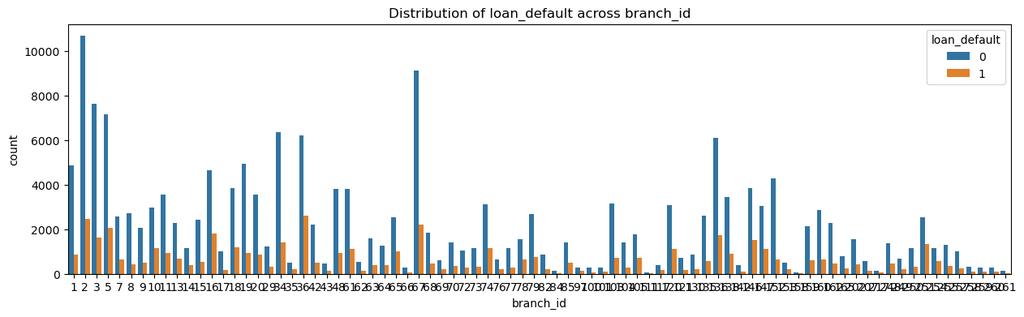

|  | supplier_id | loan_default | count |
| --- | --- | --- | --- |
| 1412 | 18166 | 0 | 1028 |
| 219 | 14375 | 0 | 988 |
| 1310 | 17980 | 0 | 983 |
| 565 | 15663 | 0 | 967 |
| 1496 | 18317 | 0 | 950 |
| ... | ... | ... | ... |
| 2211 | 21891 | 1 | 1 |
| 2199 | 21872 | 1 | 1 |
| 2198 | 21872 | 0 | 1 |
| 2187 | 21847 | 1 | 1 |
| 5564 | 24803 | 1 | 1 |

5565 rows × 3 columns

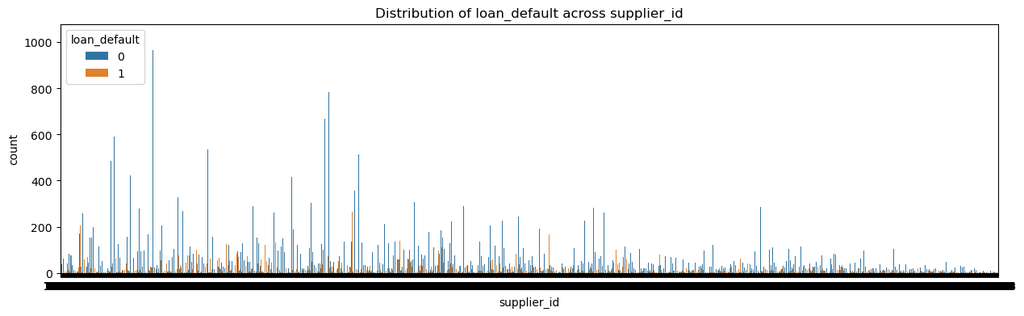

|  | manufacturer_id | loan_default | count |
| --- | --- | --- | --- |
| 10 | 86 | 0 | 87124 |
| 0 | 45 | 0 | 43687 |
| 11 | 86 | 1 | 22410 |
| 6 | 51 | 0 | 21547 |
| 1 | 45 | 1 | 12939 |
| 2 | 48 | 0 | 12156 |
| 4 | 49 | 0 | 7984 |
| 12 | 120 | 0 | 7526 |
| 7 | 51 | 1 | 5657 |
| 3 | 48 | 1 | 4554 |
| 5 | 49 | 1 | 2236 |
| 13 | 120 | 1 | 2132 |
| 8 | 67 | 0 | 1882 |
| 14 | 145 | 0 | 622 |
| 9 | 67 | 1 | 523 |
| 15 | 145 | 1 | 156 |
| 17 | 153 | 0 | 8 |
| 16 | 152 | 0 | 6 |
| 18 | 153 | 1 | 4 |
| 19 | 156 | 0 | 1 |

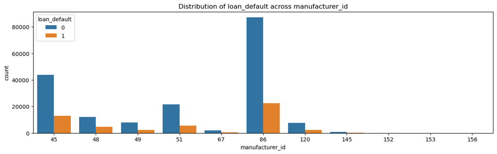

|  | State_ID | loan_default | count |
| --- | --- | --- | --- |
| 6 | 4 | 0 | 35544 |
| 4 | 3 | 0 | 27733 |
| 10 | 6 | 0 | 26615 |
| 16 | 9 | 0 | 12530 |
| 24 | 13 | 0 | 12401 |
| 14 | 8 | 0 | 10939 |
| 7 | 4 | 1 | 9326 |
| 8 | 5 | 0 | 8154 |
| 0 | 1 | 0 | 7353 |
| 11 | 6 | 1 | 6890 |
| 26 | 14 | 0 | 6817 |
| 5 | 3 | 1 | 6345 |
| 25 | 13 | 1 | 5483 |
| 12 | 7 | 0 | 5417 |
| 20 | 11 | 0 | 5348 |
| 34 | 18 | 0 | 4221 |
| 28 | 15 | 0 | 3981 |
| 17 | 9 | 1 | 3492 |
| 15 | 8 | 1 | 3258 |
| 22 | 12 | 0 | 3092 |
| 2 | 2 | 0 | 3031 |
| 32 | 17 | 0 | 3010 |
| 18 | 10 | 0 | 2972 |
| 27 | 14 | 1 | 2597 |
| 30 | 16 | 0 | 2192 |
| 9 | 5 | 1 | 2023 |
| 1 | 1 | 1 | 1583 |
| 21 | 11 | 1 | 1373 |
| 13 | 7 | 1 | 1369 |
| 35 | 18 | 1 | 1191 |
| 3 | 2 | 1 | 1129 |
| 23 | 12 | 1 | 1118 |
| 29 | 15 | 1 | 1068 |
| 33 | 17 | 1 | 981 |
| 36 | 19 | 0 | 848 |
| 19 | 10 | 1 | 633 |
| 31 | 16 | 1 | 493 |
| 37 | 19 | 1 | 187 |
| 38 | 20 | 0 | 153 |
| 40 | 21 | 0 | 125 |
| 42 | 22 | 0 | 67 |
| 39 | 20 | 1 | 32 |
| 41 | 21 | 1 | 31 |
| 43 | 22 | 1 | 9 |

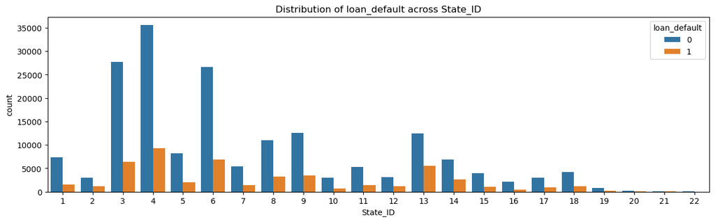

```
 I will calcaulate the rate for each category to see what items have more dafaulters rate
```

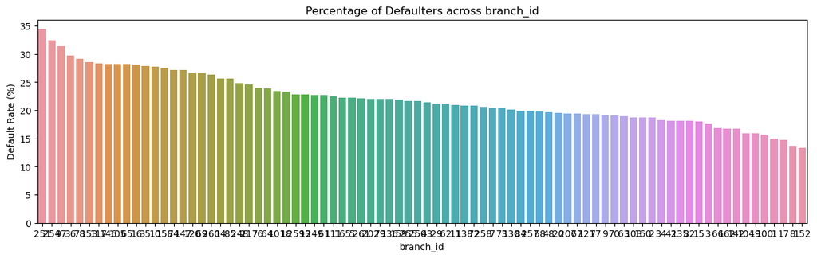

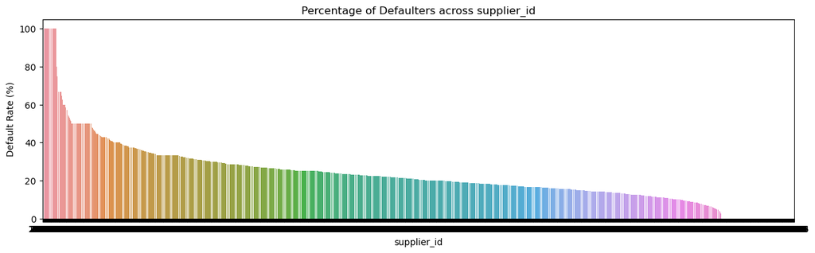

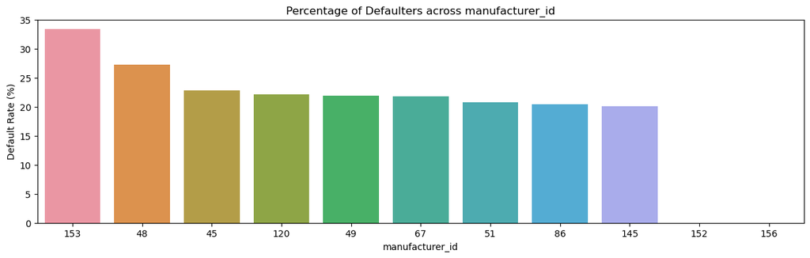

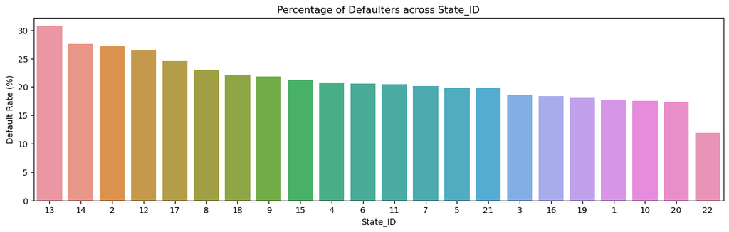

```python
categories = ['branch_id','supplier_id','manufacturer_id','State_ID']
for col in categories:
    display(
        loan
            .groupby([col,'loan_default'])['UniqueID']
            .count()
            .reset_index()
            .rename(columns = {'UniqueID' : 'count'})
            .sort_values(by = 'count' , ascending = False))

    plt.figure(figsize=(15,4))
    ax = sns.countplot(data=loan, x=col,hue='loan_default')
    ax.set_title('Distribution of loan_default across '+ col)
    plt.show()

print(" I will calcaulate the rate for each category to see what items have more dafaulters rate")
for col in categories:
    # Calculate the percentage of defaulters for each branch
    default_rate = loan.groupby(col).apply(lambda x: (x['loan_default'].sum() / x['loan_default'].count()) * 100).reset_index()
    default_rate.columns = [col, 'default_rate']

    # Sort the dataframe by default_rate for better visualization
    default_rate = default_rate.sort_values(by='default_rate', ascending=False)

    # Plotting
    plt.figure(figsize=(15,4))
    ax = sns.barplot(data=default_rate, x=col, y='default_rate', order=default_rate[col])
    ax.set_title('Percentage of Defaulters across '+col)
    plt.ylabel('Default Rate (%)')
    plt.xlabel(col)
   # plt.xticks(rotation=45)  # Rotate branch_id labels for better readability
    plt.show()


# Use this command to enable the scrolling for outputs in the notebook
display(HTML("<style>div.output_scroll { height: auto; }</style>"))
```

-What are the different employment types given in the data? Can a strategy be developed to fill in the missing values (if any)? Use pie charts to express the different types of employment that define the defaulters and non-defaulters.

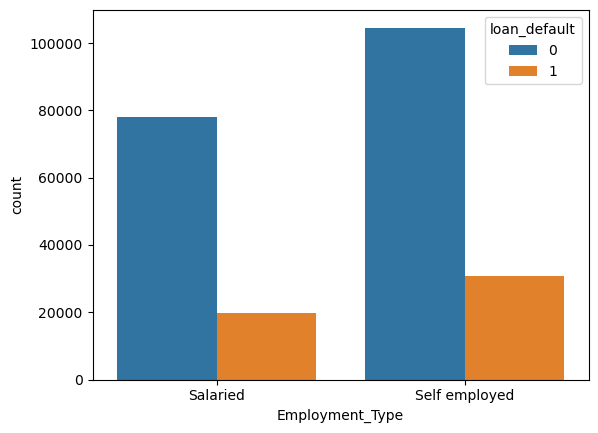

```python
d= loan.groupby(['Employment_Type','loan_default'])['UniqueID'].count().reset_index().rename(columns = {'UniqueID' : 'count'})
sns.barplot(data = d  ,x='Employment_Type' , y ='count',hue ='loan_default' )
```

```
Similar behavior across Employment Types: despite the difference in employment types, both groups exhibit somewhat comparable behavior when it comes to loan repayment. This suggests that the nature of employment (Salaried vs. Self Employed) might not be a dominant factor in determining loan default
```

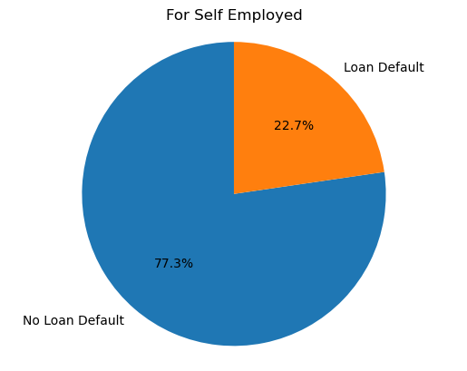

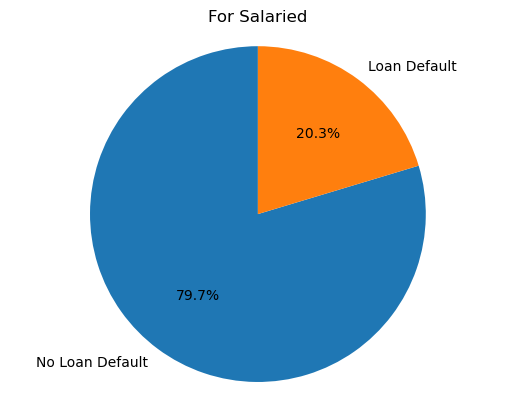

[output not shown]

```python
print("Similar behavior across Employment Types: despite the difference in employment types, \
both groups exhibit somewhat comparable behavior when it comes to loan repayment. \
This suggests that the nature of employment (Salaried vs. Self Employed) might not be a dominant factor in determining loan default")

l_self_employed = loan[loan.Employment_Type =='Self employed']
l_salaried = loan[loan.Employment_Type=='Salaried']
counts = l_self_employed['loan_default'].value_counts()
labels = ['No Loan Default', 'Loan Default']
sizes = counts.values

plt.pie(sizes, labels=labels, autopct='%1.1f%%', startangle=90)
plt.title('For Self Employed')
plt.axis('equal')  # Equal aspect ratio ensures that pie is drawn as a circle.
plt.show()

counts = l_salaried['loan_default'].value_counts()
labels = ['No Loan Default', 'Loan Default']
sizes = counts.values

plt.pie(sizes, labels=labels, autopct='%1.1f%%', startangle=90)
plt.title('For Salaried')
plt.axis('equal')  # Equal aspect ratio ensures that pie is drawn as a circle.
plt.show()
print("Regarding the missing values, I tried to use Asset_cost for finding the correspondant EmploymentType, but the average for Salaried EmploymentType : 74395.27\
and the average for Self Employed EmploymentType is : 76578.66\
There is no significant difference in the averages between the two groups. Therefore, this variable may not be helpful for imputing Employment_type.\
So I used mode for imputation in the missing value section.")
```

-Has age got anything to do with defaulting? What is the distribution of age w.r.t. to the defaulters and non-defaulters?

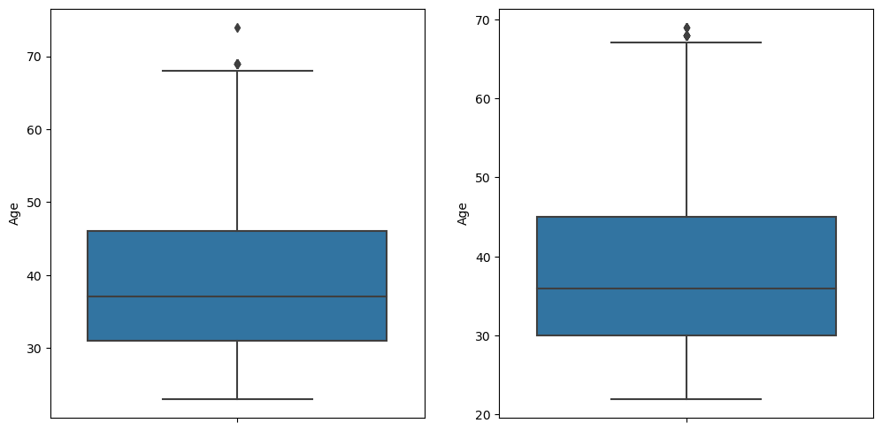

```python
fig, axes = plt.subplots(1, 2, figsize=(12, 6))
sns.boxplot(data = loan[loan.loan_default ==0] , y = 'Age' , ax=axes[0])
sns.boxplot(data = loan[loan.loan_default ==1] , y = 'Age' , ax=axes[1])
```

```
Age does seem to have a relationship with defaulting. Younger individuals are more likely to default compare to other age groups.
Approximately 23% of the young adults(19-30 years) have defaulted on their loans. As age increases, the default rate seems to slightly decrease.
```

|  | Age_Group | loan_default | count |
| --- | --- | --- | --- |
| 0 | 0-18 | 0 | 0 |
| 1 | 0-18 | 1 | 0 |
| 2 | 19-30 | 0 | 41514 |
| 3 | 19-30 | 1 | 13048 |
| 4 | 31-45 | 0 | 92745 |
| 5 | 31-45 | 1 | 25577 |
| 6 | 46-60 | 0 | 43281 |
| 7 | 46-60 | 1 | 10885 |
| 8 | 61+ | 0 | 5003 |
| 9 | 61+ | 1 | 1101 |

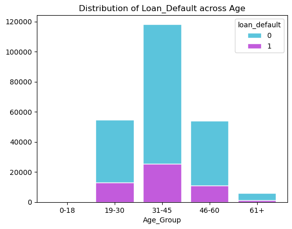

```python
print("Age does seem to have a relationship with defaulting. Younger individuals are more likely to default compare to other age groups.")
print("Approximately 23% of the young adults(19-30 years) have defaulted on their loans. As age increases, the default rate seems to slightly decrease. ")


d = loan.groupby(['Age_Group','loan_default']).count()['UniqueID'].reset_index().rename(columns = {'UniqueID':'count'})
display(d)
ax = sns.histplot(data=d , x = 'Age_Group' , hue = 'loan_default', multiple ='stack' , weights = 'count' ,
            palette=['#24b1d1', '#ae24d1'],
            edgecolor='white',
            shrink=0.8)
ax.set_title('Distribution of Loan_Default across Age')
# Remove 'Count' ylabel.
ax.set_ylabel(None)
```

-What type of ID was presented by most of the customers for proof?

```python
columns = ['MobileNo_Avl_Flag','Aadhar_flag','PAN_flag','VoterID_flag','Driving_flag','Passport_flag']
column_sums = loan[columns].sum()
print(column_sums.sort_values(ascending = False))
print("The Aadhar card is the most popular choice for ID proof among customers, \
followed by the Voter ID and then PAN card.\
The least common proof is the passport. \
The mobile number seems to be a mandatory field, as every customer in the dataset has provided it.")
```

```
MobileNo_Avl_Flag    233154
Aadhar_flag          195924
VoterID_flag          33794
PAN_flag              17621
Driving_flag           5419
Passport_flag           496
dtype: int64
The Aadhar card is the most popular choice for ID proof among customers, followed by the Voter ID and then PAN card.The least common proof is the passport. The mobile number seems to be a mandatory field, as every customer in the dataset has provided it.
```